# Heart Failure Prediction Analysis

Heart failure is a condition in which the heart can't pump enough blood to meet the body's needs. In this EDA Project, I will analyse the Heart Failure Prediction dataset through tables and charts using numpy, pandas, matplotlib and seaborn.

##### NAME: PENDEM SANJAY

##### COLLEGE: INSTITUTE OF TECHNOLOGY, GURU GHASIDAS VISHWAVIDYALAYA

### Importing the libraries:

```python
import numpy as np
import pandas as pd
import matplotlib.pyplot as plt
import seaborn as sns
%matplotlib inline
```

### Loading the Dataset:

```python
hf_df= pd.read_csv('heart_failure_clinical_records_dataset.csv')
hf_df
```

|  | age | anaemia | creatinine_phosphokinase | diabetes | ejection_fraction | high_blood_pressure | platelets | serum_creatinine | serum_sodium | sex | smoking | time | DEATH_EVENT |
| --- | --- | --- | --- | --- | --- | --- | --- | --- | --- | --- | --- | --- | --- |
| 0 | 75.0 | absent | 582 | absent | 20 | present | 265000.00 | 1.9 | 130 | male | False | 4 | Dead |
| 1 | 55.0 | absent | 7861 | absent | 38 | absent | 263358.03 | 1.1 | 136 | male | False | 6 | Dead |
| 2 | 65.0 | absent | 146 | absent | 20 | absent | 162000.00 | 1.3 | 129 | male | True | 7 | Dead |
| 3 | 50.0 | present | 111 | absent | 20 | absent | 210000.00 | 1.9 | 137 | male | False | 7 | Dead |
| 4 | 65.0 | present | 160 | present | 20 | absent | 327000.00 | 2.7 | 116 | female | False | 8 | Dead |
| ... | ... | ... | ... | ... | ... | ... | ... | ... | ... | ... | ... | ... | ... |
| 294 | 62.0 | absent | 61 | present | 38 | present | 155000.00 | 1.1 | 143 | male | True | 270 | Alive |
| 295 | 55.0 | absent | 1820 | absent | 38 | absent | 270000.00 | 1.2 | 139 | female | False | 271 | Alive |
| 296 | 45.0 | absent | 2060 | present | 60 | absent | 742000.00 | 0.8 | 138 | female | False | 278 | Alive |
| 297 | 45.0 | absent | 2413 | absent | 38 | absent | 140000.00 | 1.4 | 140 | male | True | 280 | Alive |
| 298 | 50.0 | absent | 196 | absent | 45 | absent | 395000.00 | 1.6 | 136 | male | True | 285 | Alive |

299 rows × 13 columns

```python
hf_df.info()
```

```
<class 'pandas.core.frame.DataFrame'>
RangeIndex: 299 entries, 0 to 298
Data columns (total 13 columns):
 #   Column                    Non-Null Count  Dtype
---  ------                    --------------  -----
 0   age                       299 non-null    float64
 1   anaemia                   299 non-null    object
 2   creatinine_phosphokinase  299 non-null    int64
 3   diabetes                  299 non-null    object
 4   ejection_fraction         299 non-null    int64
 5   high_blood_pressure       299 non-null    object
 6   platelets                 299 non-null    float64
 7   serum_creatinine          299 non-null    float64
 8   serum_sodium              299 non-null    int64
 9   sex                       299 non-null    object
 10  smoking                   299 non-null    bool
 11  time                      299 non-null    int64
 12  DEATH_EVENT               299 non-null    object
dtypes: bool(1), float64(3), int64(4), object(5)
memory usage: 28.4+ KB
```

##### There are 299 rows and 13 columns in the given dataset

### Data Preparation and Cleaning:

```python
hf_df.nunique()
```

```
age                          47
anaemia                       2
creatinine_phosphokinase    208
diabetes                      2
ejection_fraction            17
high_blood_pressure           2
platelets                   176
serum_creatinine             40
serum_sodium                 27
sex                           2
smoking                       2
time                        148
DEATH_EVENT                   2
dtype: int64
```

##### Checking for Null Values:

```python
hf_df.isnull().values.any()
```

```
False
```

```python
hf_df.isnull().sum()
```

```
age                         0
anaemia                     0
creatinine_phosphokinase    0
diabetes                    0
ejection_fraction           0
high_blood_pressure         0
platelets                   0
serum_creatinine            0
serum_sodium                0
sex                         0
smoking                     0
time                        0
DEATH_EVENT                 0
dtype: int64
```

###### As we can see, there are no missing values/NANs in the dataset

### Exploratory Analysis and Visualization:

```python
hf_df.head()
```

|  | age | anaemia | creatinine_phosphokinase | diabetes | ejection_fraction | high_blood_pressure | platelets | serum_creatinine | serum_sodium | sex | smoking | time | DEATH_EVENT |
| --- | --- | --- | --- | --- | --- | --- | --- | --- | --- | --- | --- | --- | --- |
| 0 | 75.0 | absent | 582 | absent | 20 | present | 265000.00 | 1.9 | 130 | male | False | 4 | Dead |
| 1 | 55.0 | absent | 7861 | absent | 38 | absent | 263358.03 | 1.1 | 136 | male | False | 6 | Dead |
| 2 | 65.0 | absent | 146 | absent | 20 | absent | 162000.00 | 1.3 | 129 | male | True | 7 | Dead |
| 3 | 50.0 | present | 111 | absent | 20 | absent | 210000.00 | 1.9 | 137 | male | False | 7 | Dead |
| 4 | 65.0 | present | 160 | present | 20 | absent | 327000.00 | 2.7 | 116 | female | False | 8 | Dead |

##### NO OF PARTICIPANTS:

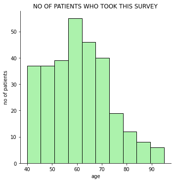

```python
plt.figure(figsize=(12,6));
sns.displot(hf_df.age, color='lightgreen');
plt.title("NO OF PATIENTS WHO TOOK THIS SURVEY");
plt.ylabel("no of patients");
```

##### PATIENTS WITH DIABETES:

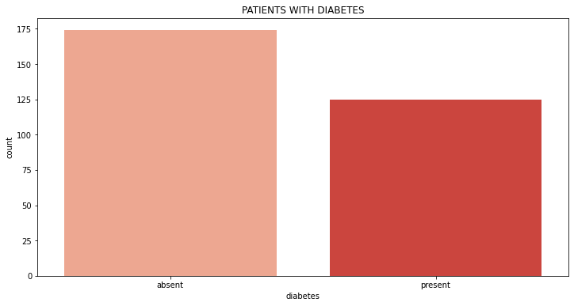

```python
plt.figure(figsize=(12,6))

plt.title('PATIENTS WITH DIABETES')
sns.countplot(x=hf_df.diabetes, palette="Reds");
```

##### PATIENTS WITH COMORBIDITIES:

```python
comorbidities=hf_df[['age','anaemia','diabetes','high_blood_pressure']]
comorbidities
```

|  | age | anaemia | diabetes | high_blood_pressure |
| --- | --- | --- | --- | --- |
| 0 | 75.0 | absent | absent | present |
| 1 | 55.0 | absent | absent | absent |
| 2 | 65.0 | absent | absent | absent |
| 3 | 50.0 | present | absent | absent |
| 4 | 65.0 | present | present | absent |
| ... | ... | ... | ... | ... |
| 294 | 62.0 | absent | present | present |
| 295 | 55.0 | absent | absent | absent |
| 296 | 45.0 | absent | present | absent |
| 297 | 45.0 | absent | absent | absent |
| 298 | 50.0 | absent | absent | absent |

299 rows × 4 columns

##### PATIENTS WITH HIGH BLOOD PRESSURE:

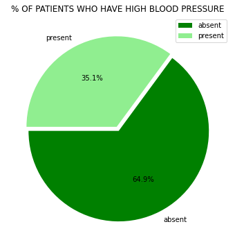

```python
plt.figure(figsize=(12,6))
plt.title("% OF PATIENTS WHO HAVE HIGH BLOOD PRESSURE")
plt.pie(hf_df.high_blood_pressure	.value_counts(), explode=(0.025,0.025), labels=hf_df.high_blood_pressure	.value_counts().index, colors=['green','lightgreen'],autopct='%1.1f%%', startangle=180);
plt.legend();
```

##### PATIENTS WHO SMOKE:

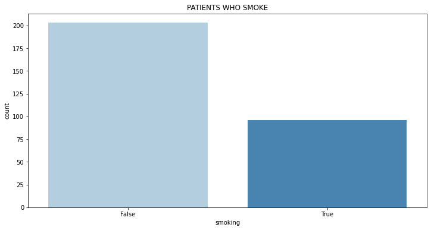

```python
plt.figure(figsize=(12,6))

plt.title("PATIENTS WHO SMOKE")
sns.countplot(x=hf_df.smoking, palette="Blues");
```

##### SERUM CREATININE LEVELS IN BLOOD:

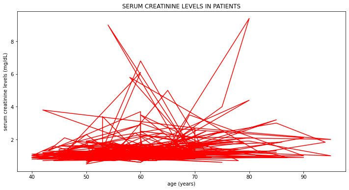

```python
plt.figure(figsize=(12,6))
plt.title("SERUM CREATININE LEVELS IN PATIENTS")
plt.xlabel("age (years)")
plt.ylabel("serum creatinine levels (mg/dL)")
plt.plot(hf_df.age,hf_df.serum_creatinine,"-r");
```

##### From the above chart, we can conclude that most of the patients have serum creatinine levels below 2 mg/dL

###### SERUM SODIUM LEVELS IN BLOOD:

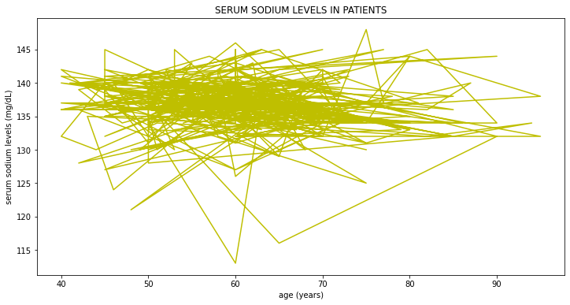

```python
plt.figure(figsize=(12,6))
plt.title("SERUM SODIUM LEVELS IN PATIENTS")
plt.xlabel("age (years)")
plt.ylabel("serum sodium levels (mg/dL)")
plt.plot(hf_df.age,hf_df.serum_sodium,"-y");
```

##### Most of the patients have sodium levels between 130-145 dg/mL

##### EJECTION FRACTION:

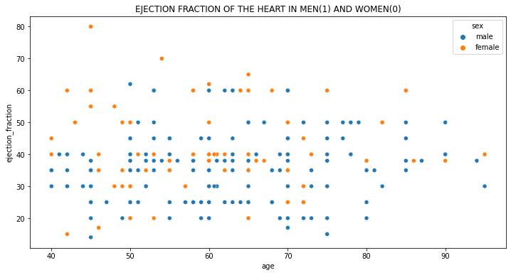

```python
plt.figure(figsize=(12,6))
sns.scatterplot(x=hf_df.age, y=hf_df.ejection_fraction,hue=hf_df.sex,legend=True)
plt.title("EJECTION FRACTION OF THE HEART IN MEN(1) AND WOMEN(0)");
```

### QUESTIONS AND ANSWERS:

##### Q1: How many patients have all three comorbidities?

```python
a=hf_df.loc[(hf_df['diabetes'] == 'present') & (hf_df['anaemia'] == 'present') & (hf_df['high_blood_pressure'] == 'present')]
counter=a.age.count()
print(counter)
```

```
17
```

##### Q2: What are the ages of youngest and oldest people who took part in this survey?

```python
oldest=max(hf_df.age)
youngest=min(hf_df.age)
print("Oldest:", oldest)
print("Youngest:", youngest)
```

```
Oldest: 95.0
Youngest: 40.0
```

```python
hf_df[['smoking','platelets']]
```

|  | smoking | platelets |
| --- | --- | --- |
| 0 | False | 265000.00 |
| 1 | False | 263358.03 |
| 2 | True | 162000.00 |
| 3 | False | 210000.00 |
| 4 | False | 327000.00 |
| ... | ... | ... |
| 294 | True | 155000.00 |
| 295 | False | 270000.00 |
| 296 | False | 742000.00 |
| 297 | True | 140000.00 |
| 298 | True | 395000.00 |

299 rows × 2 columns

##### Q4: What is the average levels of creatinine phosphokinase for those people in age group 40-50?

```python
agecount=(hf_df.age>=40) &(hf_df.age<50)
average=hf_df[agecount].age.count()
average
sumofcreatinine=hf_df[agecount].creatinine_phosphokinase.sum()

average_levels=sumofcreatinine/average
print("Average:",average_levels )
```

```
Average: 802.1489361702128
```

##### Q5: Does the person with the highest platelet count have any comorbidities?

```python
maximum= max(hf_df.platelets)
hf_df.loc[hf_df['platelets'] == maximum]
```

|  | age | anaemia | creatinine_phosphokinase | diabetes | ejection_fraction | high_blood_pressure | platelets | serum_creatinine | serum_sodium | sex | smoking | time | DEATH_EVENT |
| --- | --- | --- | --- | --- | --- | --- | --- | --- | --- | --- | --- | --- | --- |
| 109 | 45.0 | absent | 292 | present | 35 | absent | 850000.0 | 1.3 | 142 | male | True | 88 | Dead |

yes, the patient has diabetes